# Covid 19 Project

Ryan Masad

2023-09-17

## Covid 19 Project

In this project we will be analyzing data for Covid 19 cases across the world. We will start by importing Covid 19 time series data directly from the Johns Hopkins Coronavirus Resource Center Github focused across 4 datasets.

1. US Cases
2. US Deaths
3. Global Cases
4. Global Deaths

```r
url_in = "https://raw.githubusercontent.com/CSSEGISandData/COVID-19/master/csse_covid_19_data/csse_covid_19_time_series/"
file_names = c("time_series_covid19_confirmed_US.csv",  "time_series_covid19_confirmed_global.csv", "time_series_covid19_deaths_US.csv",  "time_series_covid19_deaths_global.csv")
url_files = str_c(url_in,file_names)
url_files
```

```
## [1] "https://raw.githubusercontent.com/CSSEGISandData/COVID-19/master/csse_covid_19_data/csse_covid_19_time_series/time_series_covid19_confirmed_US.csv"
## [2] "https://raw.githubusercontent.com/CSSEGISandData/COVID-19/master/csse_covid_19_data/csse_covid_19_time_series/time_series_covid19_confirmed_global.csv"
## [3] "https://raw.githubusercontent.com/CSSEGISandData/COVID-19/master/csse_covid_19_data/csse_covid_19_time_series/time_series_covid19_deaths_US.csv"
## [4] "https://raw.githubusercontent.com/CSSEGISandData/COVID-19/master/csse_covid_19_data/csse_covid_19_time_series/time_series_covid19_deaths_global.csv"
```

### Importing The Data

In the previous step we gathered the urls for loading the data. Now we are pulling them into CSVs.

```r
us_cases = read.csv(url_files[1])
global_cases = read.csv(url_files[2])
us_deaths = read.csv(url_files[3])
global_deaths = read.csv(url_files[4])
```

### US Cases Data Cleaning

Next we are going to import and clean US Cases. We are only keeping County, State, Country, Combined Key, Date, Lat, Long and cases. We pivot date and cases to be more like a dataset.

```r
us_cases = us_cases %>%
  pivot_longer(cols = -c(UID:Combined_Key),
                                     names_to = "date", values_to = "cases") %>%
  select(Admin2, Province_State,Country_Region, Combined_Key, date, Lat, Long_, cases)
us_cases %>% head(5)
```

```
## # A tibble: 5 × 8
##   Admin2  Province_State Country_Region Combined_Key     date    Lat Long_ cases
##   <chr>   <chr>          <chr>          <chr>            <chr> <dbl> <dbl> <int>
## 1 Autauga Alabama        US             Autauga, Alabam… X1.2…  32.5 -86.6     0
## 2 Autauga Alabama        US             Autauga, Alabam… X1.2…  32.5 -86.6     0
## 3 Autauga Alabama        US             Autauga, Alabam… X1.2…  32.5 -86.6     0
## 4 Autauga Alabama        US             Autauga, Alabam… X1.2…  32.5 -86.6     0
## 5 Autauga Alabama        US             Autauga, Alabam… X1.2…  32.5 -86.6     0
```

We repeat this for Us_deaths following the same process as above.

```r
us_deaths = us_deaths %>%
  pivot_longer(cols = -c(UID:Population),
                                       names_to = "date", values_to = "deaths") %>%
  select(Admin2, Province_State,Country_Region, Combined_Key, Population, date, Lat, Long_, deaths)
us_deaths %>% head(5)
```

```
## # A tibble: 5 × 9
##   Admin2 Province_State Country_Region Combined_Key Population date    Lat Long_
##   <chr>  <chr>          <chr>          <chr>             <int> <chr> <dbl> <dbl>
## 1 Autau… Alabama        US             Autauga, Al…      55869 X1.2…  32.5 -86.6
## 2 Autau… Alabama        US             Autauga, Al…      55869 X1.2…  32.5 -86.6
## 3 Autau… Alabama        US             Autauga, Al…      55869 X1.2…  32.5 -86.6
## 4 Autau… Alabama        US             Autauga, Al…      55869 X1.2…  32.5 -86.6
## 5 Autau… Alabama        US             Autauga, Al…      55869 X1.2…  32.5 -86.6
## # ℹ 1 more variable: deaths <int>
```

Next we will join these 2 datasets together, so we can analyze cases and deaths at the same time.

```r
us = full_join(us_cases,us_deaths, by= c("Admin2", "Province_State", "Country_Region", "Combined_Key" , "date", "Lat", "Long_"))
us$date = as.Date(substr(us$date,2,nchar(us$date)), format = "%m.%d.%y")
us = us %>% rename(Province = Admin2)
us %>% head(5)
```

```
## # A tibble: 5 × 10
##   Province Province_State Country_Region Combined_Key     date         Lat Long_
##   <chr>    <chr>          <chr>          <chr>            <date>     <dbl> <dbl>
## 1 Autauga  Alabama        US             Autauga, Alabam… 2020-01-22  32.5 -86.6
## 2 Autauga  Alabama        US             Autauga, Alabam… 2020-01-23  32.5 -86.6
## 3 Autauga  Alabama        US             Autauga, Alabam… 2020-01-24  32.5 -86.6
## 4 Autauga  Alabama        US             Autauga, Alabam… 2020-01-25  32.5 -86.6
## 5 Autauga  Alabama        US             Autauga, Alabam… 2020-01-26  32.5 -86.6
## # ℹ 3 more variables: cases <int>, Population <int>, deaths <int>
```

```r
summary(us)
```

```
##    Province         Province_State     Country_Region     Combined_Key
##  Length:3819906     Length:3819906     Length:3819906     Length:3819906
##  Class :character   Class :character   Class :character   Class :character
##  Mode  :character   Mode  :character   Mode  :character   Mode  :character
##
##
##
##       date                 Lat             Long_             cases
##  Min.   :2020-01-22   Min.   :-14.27   Min.   :-174.16   Min.   :  -3073
##  1st Qu.:2020-11-02   1st Qu.: 33.90   1st Qu.: -97.81   1st Qu.:    330
##  Median :2021-08-15   Median : 38.01   Median : -89.49   Median :   2272
##  Mean   :2021-08-15   Mean   : 36.72   Mean   : -88.64   Mean   :  14088
##  3rd Qu.:2022-05-28   3rd Qu.: 41.58   3rd Qu.: -82.31   3rd Qu.:   8159
##  Max.   :2023-03-09   Max.   : 69.31   Max.   : 145.67   Max.   :3710586
##    Population           deaths
##  Min.   :       0   Min.   :  -82.0
##  1st Qu.:    9917   1st Qu.:    4.0
##  Median :   24892   Median :   37.0
##  Mean   :   99604   Mean   :  186.9
##  3rd Qu.:   64979   3rd Qu.:  122.0
##  Max.   :10039107   Max.   :35545.0
```

### US Totals Analysis

Here we will start analyzing the data for US cases. I am going to start by creating a simple trends analysis. We will look cases across the US. This lets us circle in on Cases per day and when we spiked.

```r
us_totals = us %>%
  group_by(Country_Region, date) %>%
  summarise(cases = sum(cases), deaths = sum(deaths), population = max(Population)) %>%

  mutate(cases_pm = cases/population*1000000) %>%
  mutate(deaths_pm = deaths/population*1000000) %>%
  mutate(daily_cases = cases-lag(cases)) %>%
  mutate(daily_deaths = deaths-lag(deaths)) %>%
  mutate(cases_per_thou = daily_cases/population*1000) %>%
  mutate(deaths_per_thou = daily_deaths/population*1000)
us_totals %>% head(5)
```

```
## # A tibble: 5 × 11
## # Groups:   Country_Region [1]
##   Country_Region date       cases deaths population cases_pm deaths_pm
##   <chr>          <date>     <int>  <int>      <int>    <dbl>     <dbl>
## 1 US             2020-01-22     1      1   10039107   0.0996    0.0996
## 2 US             2020-01-23     1      1   10039107   0.0996    0.0996
## 3 US             2020-01-24     2      1   10039107   0.199     0.0996
## 4 US             2020-01-25     2      1   10039107   0.199     0.0996
## 5 US             2020-01-26     5      1   10039107   0.498     0.0996
## # ℹ 4 more variables: daily_cases <int>, daily_deaths <int>,
## #   cases_per_thou <dbl>, deaths_per_thou <dbl>
```

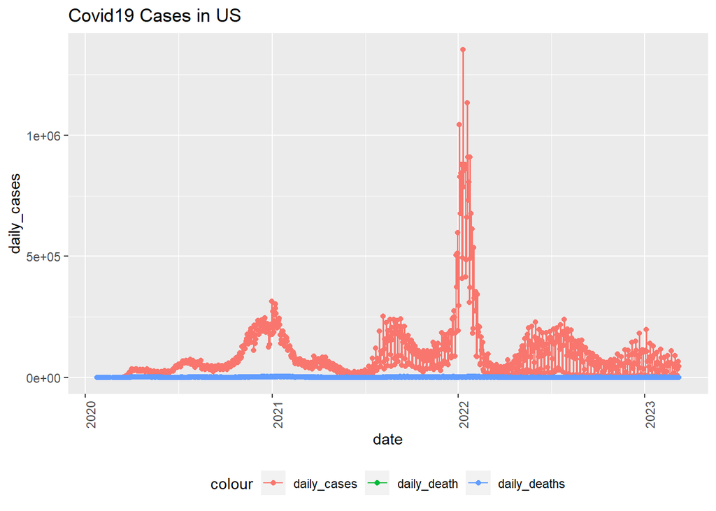

### Model

Next we will perform a simple linear model to look at the correlation between cases and deaths. We converted the cases and deaths into cases per though people per day to make the numbers a ratio to add scale to the problem.

```r
mod= lm(deaths_per_thou ~ cases_per_thou, data = us_totals)
summary(mod)
```

```
##
## Call:
## lm(formula = deaths_per_thou ~ cases_per_thou, data = us_totals)
##
## Residuals:
##      Min       1Q   Median       3Q      Max
## -0.35861 -0.05775 -0.02348  0.03190  0.30209
##
## Coefficients:
##                 Estimate Std. Error t value Pr(>|t|)
## (Intercept)    0.0646070  0.0029091   22.21   <2e-16 ***
## cases_per_thou 0.0036910  0.0001875   19.69   <2e-16 ***
## ---
## Signif. codes:  0 '***' 0.001 '**' 0.01 '*' 0.05 '.' 0.1 ' ' 1
##
## Residual standard error: 0.07984 on 1140 degrees of freedom
##   (1 observation deleted due to missingness)
## Multiple R-squared:  0.2537, Adjusted R-squared:  0.2531
## F-statistic: 387.6 on 1 and 1140 DF,  p-value: < 2.2e-16
```

```r
x_grid = seq(1,151)
```

## Global Cases Data Cleaning

Here we will repeat the cleaning done previously. We will clean the data for global cases and deaths.

```r
global_cases = global_cases %>%
  pivot_longer(cols = -c(Province.State:Long),
               names_to = "date", values_to = "cases") %>%
  select(Province.State, Country.Region, date, Lat, Long , cases)
global_cases %>% head(5)
```

```
## # A tibble: 5 × 6
##   Province.State Country.Region date       Lat  Long cases
##   <chr>          <chr>          <chr>    <dbl> <dbl> <int>
## 1 ""             Afghanistan    X1.22.20  33.9  67.7     0
## 2 ""             Afghanistan    X1.23.20  33.9  67.7     0
## 3 ""             Afghanistan    X1.24.20  33.9  67.7     0
## 4 ""             Afghanistan    X1.25.20  33.9  67.7     0
## 5 ""             Afghanistan    X1.26.20  33.9  67.7     0
```

```r
global_deaths = global_deaths %>%
  pivot_longer(cols = -c(Province.State:Long),
               names_to = "date", values_to = "deaths") %>%
  select(Province.State, Country.Region, date, Lat, Long , deaths)
global_deaths %>% head(5)
```

```
## # A tibble: 5 × 6
##   Province.State Country.Region date       Lat  Long deaths
##   <chr>          <chr>          <chr>    <dbl> <dbl>  <int>
## 1 ""             Afghanistan    X1.22.20  33.9  67.7      0
## 2 ""             Afghanistan    X1.23.20  33.9  67.7      0
## 3 ""             Afghanistan    X1.24.20  33.9  67.7      0
## 4 ""             Afghanistan    X1.25.20  33.9  67.7      0
## 5 ""             Afghanistan    X1.26.20  33.9  67.7      0
```

After doing initial cleaning, Global is missing population information, so we are going to get it.

[output not shown]

Here we are joining the 2 global datasets + the Population Dataset and cleaning up date to remove X and format as a date.

```r
global = full_join(global_cases,global_deaths, by= c("Province.State", "Country.Region", "date", "Lat", "Long"))
global = left_join(global,global_population, by= c("Province.State", "Country.Region"))

global$date = as.Date(substr(global$date,2,nchar(global$date)), format = "%m.%d.%y")
global = global %>% rename(Province = Admin2, Province_State = Province.State, Country_Region = Country.Region)
global %>% head(5)
```

```
## # A tibble: 5 × 10
##   Province_State Country_Region date         Lat  Long cases deaths Province
##   <chr>          <chr>          <date>     <dbl> <dbl> <int>  <int> <chr>
## 1 ""             Afghanistan    2020-01-22  33.9  67.7     0      0 ""
## 2 ""             Afghanistan    2020-01-23  33.9  67.7     0      0 ""
## 3 ""             Afghanistan    2020-01-24  33.9  67.7     0      0 ""
## 4 ""             Afghanistan    2020-01-25  33.9  67.7     0      0 ""
## 5 ""             Afghanistan    2020-01-26  33.9  67.7     0      0 ""
## # ℹ 2 more variables: Combined_Key <chr>, Population <int>
```

### Global Cases Analysis

We will do a similar analysis to see how global cases trended. One thing to note is there are a few more spikes then the US dataset due to different countries having spikes at different times.

```r
global_totals = global %>%
  group_by(date) %>%
  summarise(cases = sum(cases), deaths = sum(deaths)) %>%
  mutate(daily_cases = cases-lag(cases)) %>%
  mutate(daily_deaths = deaths-lag(deaths))
global_totals %>% head(5)
```

```
## # A tibble: 5 × 5
##   date       cases deaths daily_cases daily_deaths
##   <date>     <int>  <int>       <int>        <int>
## 1 2020-01-22   557     17          NA           NA
## 2 2020-01-23   657     18         100            1
## 3 2020-01-24   944     26         287            8
## 4 2020-01-25  1437     42         493           16
## 5 2020-01-26  2120     56         683           14
```

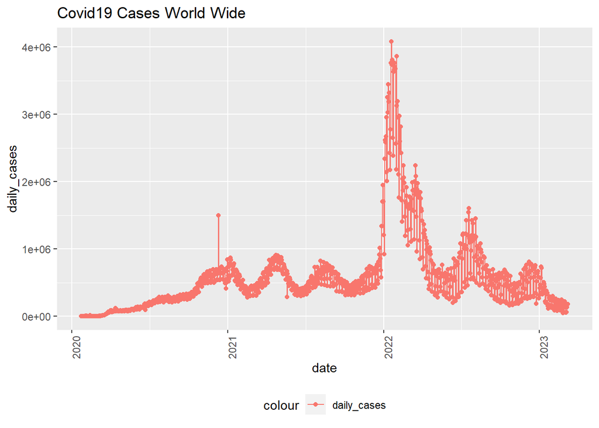

### Analysis by Country

```r
country_totals = global %>%
  group_by(Country_Region, Lat, Long) %>%
  summarise(cases = max(cases), deaths = max(deaths), population = max(Population)) %>%
  mutate(cases_pm = cases/population*1000000) %>%
  mutate(deaths_pm = deaths/population*1000000)
country_totals %>% head(5)
```

```
## # A tibble: 5 × 8
## # Groups:   Country_Region, Lat [5]
##   Country_Region   Lat  Long  cases deaths population cases_pm deaths_pm
##   <chr>          <dbl> <dbl>  <int>  <int>      <int>    <dbl>     <dbl>
## 1 Afghanistan     33.9 67.7  209451   7896   38928341    5380.     203.
## 2 Albania         41.2 20.2  334457   3598    2877800  116220.    1250.
## 3 Algeria         28.0  1.66 271496   6881   43851043    6191.     157.
## 4 Andorra         42.5  1.52  47890    165      77265  619815.    2136.
## 5 Angola         -11.2 17.9  105288   1933   32866268    3204.      58.8
```

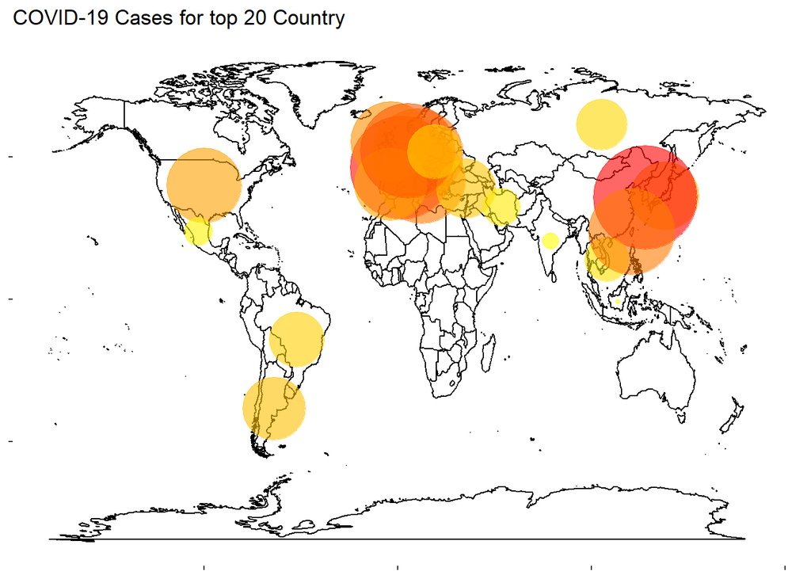

[figure not shown]

## Conclusion

In conclusion, after this precursory analysis of Covid 19 cases, I have a better understanding of where spikes occurred and what countries had the most cases. One are of bias is that this dataset depends on reporting accuracy. There is no guarantee that every country reports accurately. Another issue is that because it is based off people testing, it depends on how much a country tested. this means that cases could be worse in other countries because of under reporting.